# Systems-level metabolic differences associated with antibiotic resistance in *Pseudomonas aeruginosa*

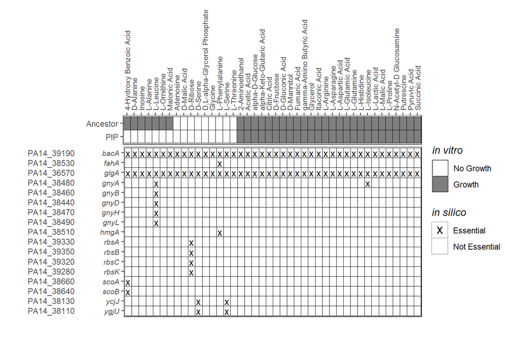

**Fig 5. Model-guided prediction of loss of metabolic function in piperacillin-evolved *P. aeruginosa*.** Experimental growth calls of the piperacillin-evolved and ancestral lineages on carbon sources able to support growth on the base iPau1129 model (top). Model predicted genes essential for growth on minimal media with each carbon source (bottom). Only the subset of essential genes that were found to be deleted in the piperacillin-evolved lineage are included (*In vitro*: white = no growth, grey = growth; *in silico*: X = essential gene, blank = non-essential gene).

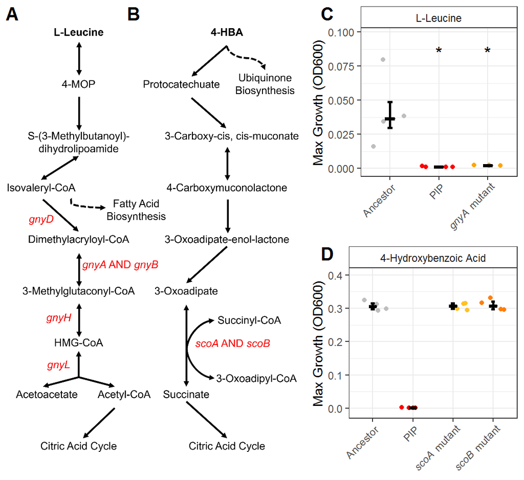

```
## # A tibble: 3 x 5
## # Groups:   strain [?]
##   strain  media     medianMaxOD600    IQ25    IQ75
##   <fct>   <chr>              <dbl>   <dbl>   <dbl>
## 1 Day0Anc L-Leucine        0.0364  0.0298  0.0488
## 2 Day20P1 L-Leucine        0.00115 0.00115 0.00131
## 3 gnyA    L-Leucine        0.00220 0.00205 0.00236
```

```
## # A tibble: 3 x 7
## # Groups:   strain, media [3]
##   strain  media     timeTidy medianOD600     IQ25     IQ75 AUCmedian
##   <fct>   <chr>        <dbl>       <dbl>    <dbl>    <dbl>     <dbl>
## 1 Day0Anc L-Leucine    48.0       0.122  0.0299   0.0490    0.0364
## 2 Day20P1 L-Leucine    28.5       0.0860 0.000275 0.000675  0.000600
## 3 gnyA    L-Leucine     8.51      0.0875 0.00185  0.00214   0.00202
```

```
## # A tibble: 4 x 5
## # Groups:   strain [?]
##   strain  media                 medianMaxOD600    IQ25    IQ75
##   <fct>   <chr>                          <dbl>   <dbl>   <dbl>
## 1 Day0Anc 4-Hydroxybenzoic Acid        0.306   0.298   0.315
## 2 Day20P1 4-Hydroxybenzoic Acid        0.00185 0.00169 0.00205
## 3 scoA    4-Hydroxybenzoic Acid        0.307   0.298   0.315
## 4 scoB    4-Hydroxybenzoic Acid        0.307   0.297   0.320
```

```
## # A tibble: 4 x 7
## # Groups:   strain, media [4]
##   strain  media             timeTidy medianOD600    IQ25    IQ75 AUCmedian
##   <fct>   <chr>                <dbl>       <dbl>   <dbl>   <dbl>     <dbl>
## 1 Day0Anc 4-Hydroxybenzoic~     38.8      0.389  2.92e-1 0.313    0.303
## 2 Day20P1 4-Hydroxybenzoic~      0        0.0862 6.87e-4 0.00110  0.000825
## 3 scoA    4-Hydroxybenzoic~     41.1      0.388  2.97e-1 0.307    0.302
## 4 scoB    4-Hydroxybenzoic~     38.3      0.389  2.91e-1 0.318    0.304
```

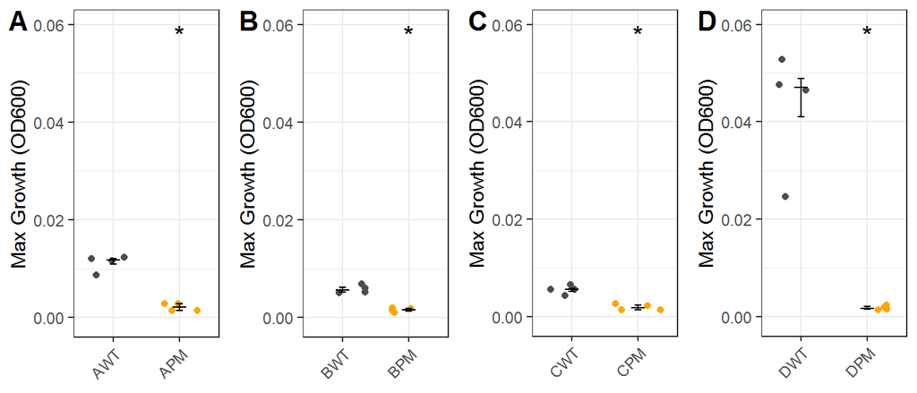

** Fig 7. Clinical isolates with large deletions exhibit loss of catabolic function similar to piperacillin-evolved *P. aeruginosa*.** Median maximum growth of clinical isolates from (Hocquet et al., 2016) with large chromosomal deletions (PM) and paired parental wild type (WT) isolates without large deletions in L-leucine. Growth was measured on four isolate pairs: (A) AWT and APM, (B) BWT and BPM, (C) CWT and CPM, and (D) DWT and DPM. Significance determined by Wilcoxon rank sum test (P-value < 0.05). Error bars show the interquartile range of four replicate colonies.

## **Supplemental Figures and Data**

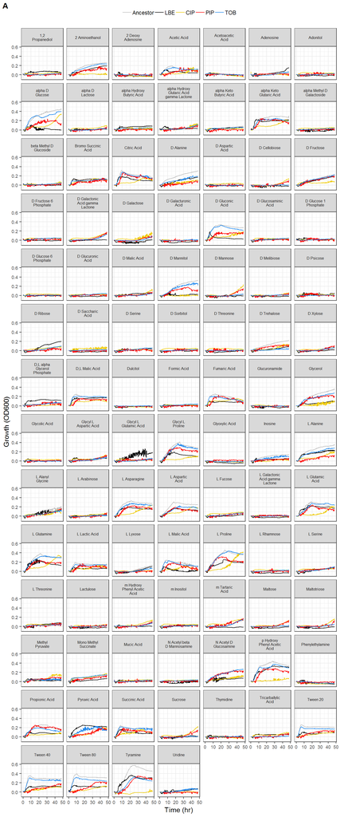

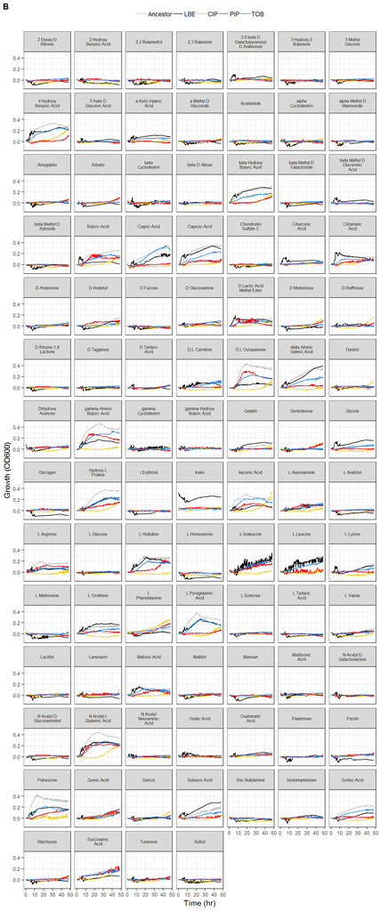

**S1 Fig. Growth curves of all lineages on all carbon sources.** Median 48-hour growth curves of the five lineages (ancestral, LB-evolved, CIP-evolved, PIP-evolved, TOB-evolved) on 190 carbon sources. (A) Growth on carbon sources from Phenotypic Microarray Plate PM1. (B) Growth on carbon sources from Phenotypic Microarray Plate PM2a. Each curve represents the average of three biological replicates. Growth is measured as the OD600 - background, where the background was an inoculated well containing media with no carbon source.

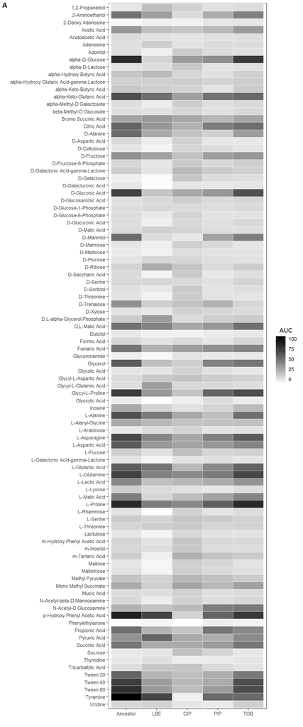

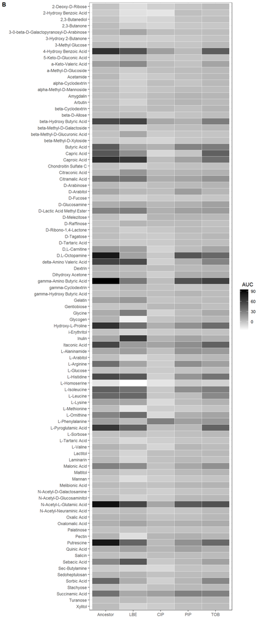

**S3 Fig. Area under the curve (AUC) on all carbon sources by lineage.** The total median AUC for each lineage on 190 carbon sources where the AUC = sum(growth curve - background). (A) Phenotypic Microarray Plate PM1. (B) Phenotypic Microarray Plate PM2a. The growth curves and backgrounds were averaged across three biological replicates. A lineage was considered to have grown on a given carbon source if the AUC was in the upper quantile.

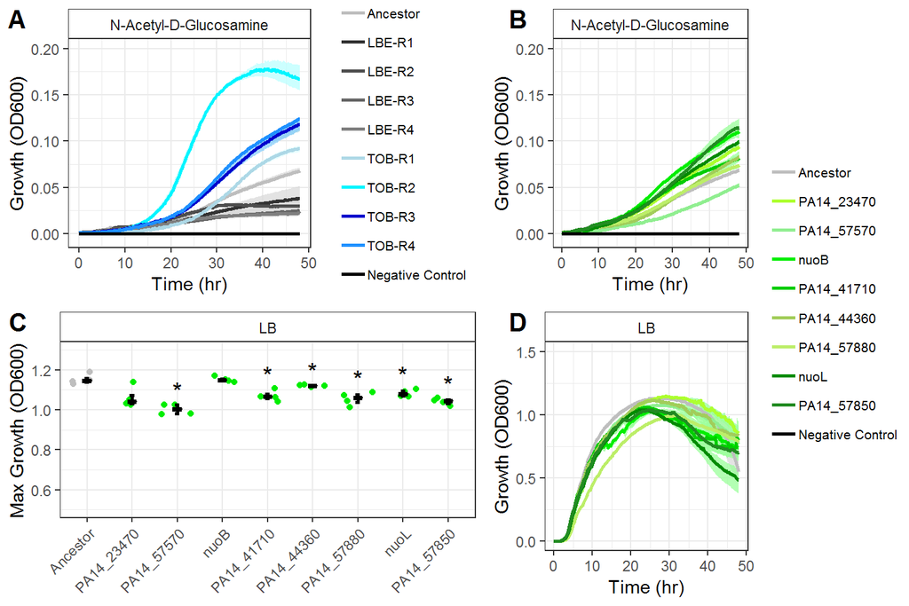

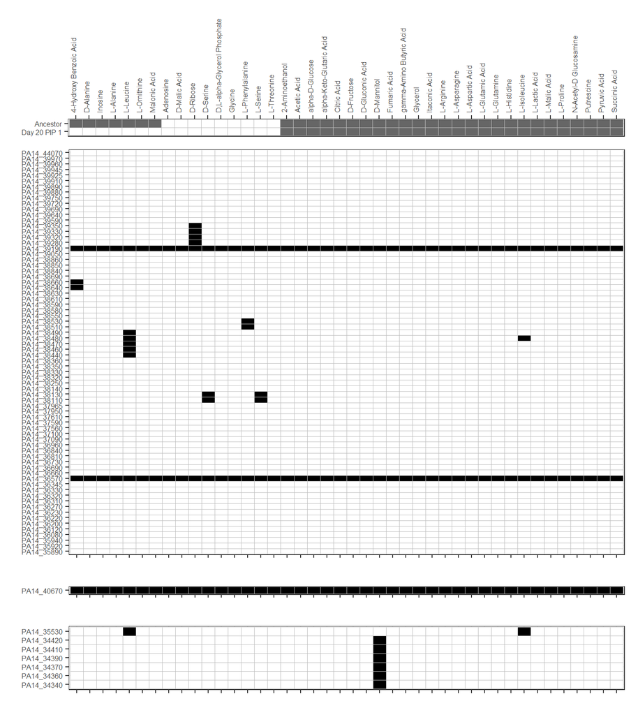

**S5 Fig. Complete essentiality predictions in the PIP large deletion.** A) Expansion of Fig 5 that includes all genes that were deleted in the piperacillin-evolved lineage and are included in the iPau1129 GENRE. Additional unique essential gene predictions for B) lineage Day 20 Pip Replicate 2 and C) lineage Day 20 Pip Replicate 3. (*In vitro*: white = no growth, grey = growth; *in silico*: black = essential gene, white = non-essential gene).

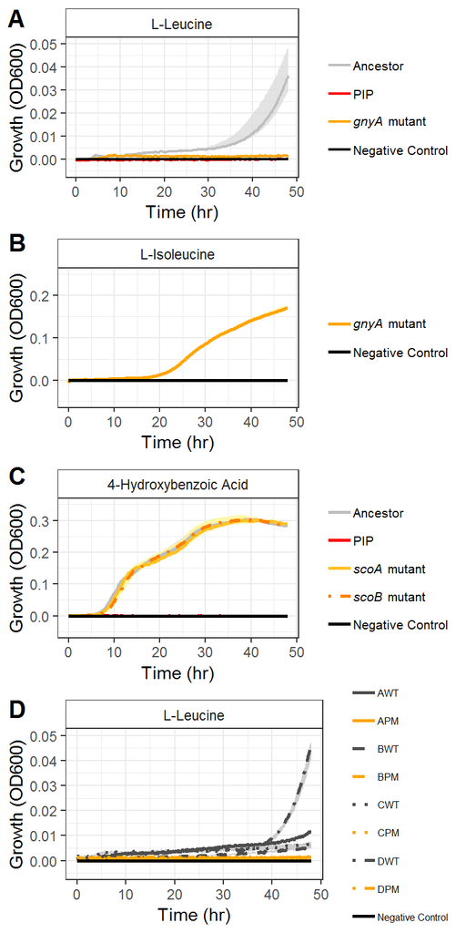

[output not shown]

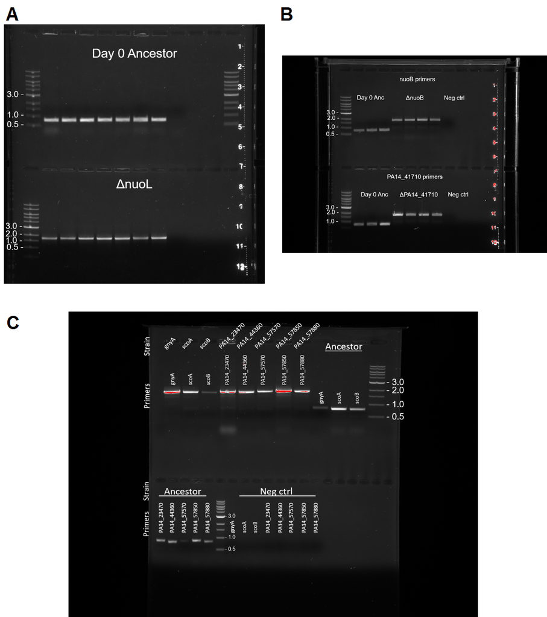

**S7 Fig. Verification of a transposon insertions via PCR.** The ancestral lineage (top), had a PCR product between 0.5-1kb while the *nuoL* transposon mutant (bottom) had a product between 1-2kb.

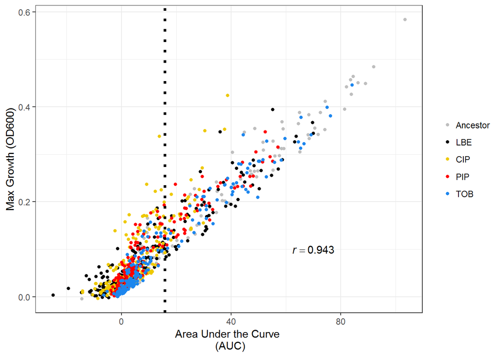

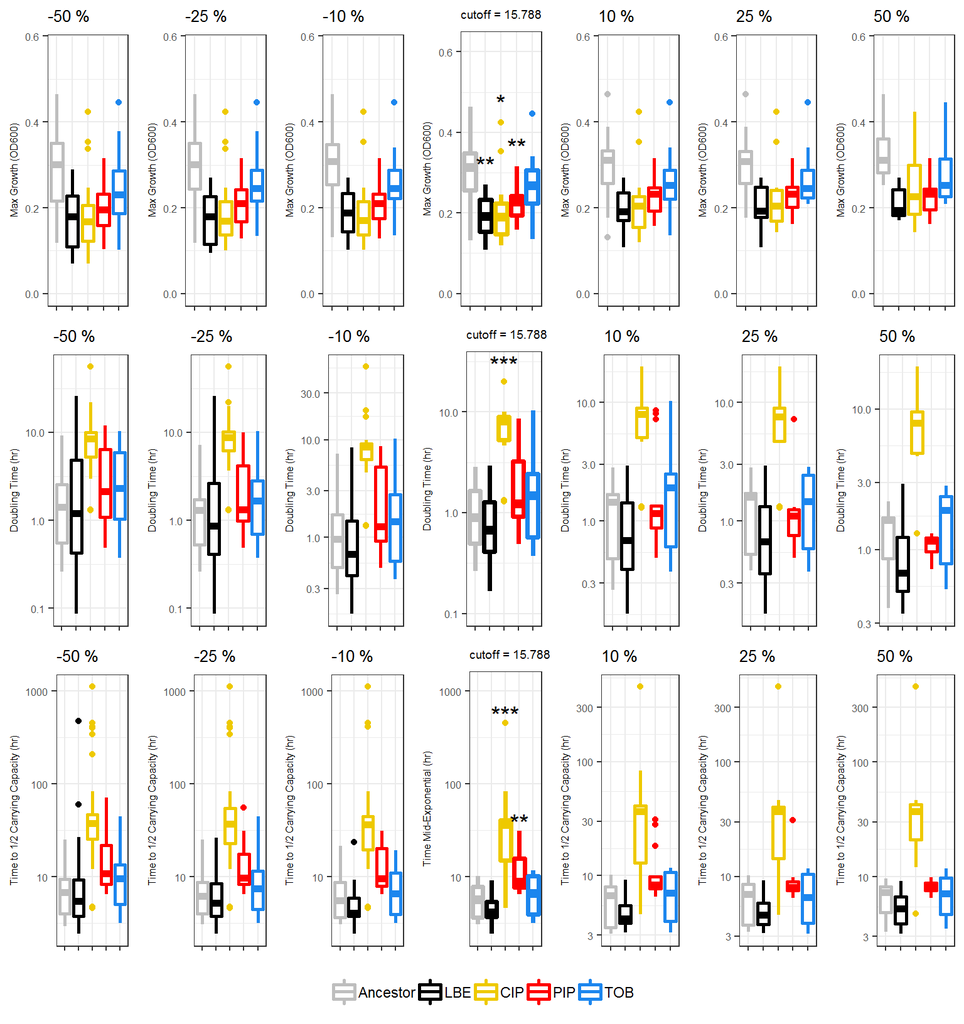

### Generate S1_Raw Data for S1 Code

### Supplementary Text: Statistical Tests

Figure 2C Statistics: Maximum Growth (OD600): 1. Ancestor vs LBE 2. Ancestor vs CIP 3. Ancestor vs PIP 4. Ancestor vs TOB

```
## [1] 8.576815e-06 6.935045e-05 6.474856e-06 1.920510e-03
```

```
## [1] 1.715363e-05 9.246727e-05 1.715363e-05 1.920510e-03
```

Figure 3D Statistics Maximum Growth (OD600) 1. Ancestor vs LBE 2. Ancestor vs CIP 3. Ancestor vs PIP 4. Ancestor vs TOB

```
## [1] 0.0008647034 0.0082420099 0.0047165304 0.1752721392
```

```
## [1] 0.003458813 0.010989347 0.009433061 0.175272139
```

Figure 3E Statistics Growth Rate 1. Ancestor vs LBE 2. Ancestor vs CIP 3. Ancestor vs PIP 4. Ancestor vs TOB

```
## [1] 0.2602848339 0.0001247335 0.2602848339 0.1237439386
```

```
## [1] 0.2602848339 0.0004989341 0.2602848339 0.2474878772
```

Figure 3F Statistics Time to Mid-Exponential Phase 1. Ancestor vs LBE 2. Ancestor vs CIP 3. Ancestor vs PIP 4. Ancestor vs TOB

```
## [1] 0.3462297896 0.0001502332 0.0040823159 0.4213482327
```

```
## [1] 0.4213482327 0.0006009329 0.0081646317 0.4213482327
```

Figure 4A Statistics - Updated Maximum Growth (OD600) Ancestor vs LBE-R1 Ancestor vs LBE-R2 Ancestor vs LBE-R3 Ancestor vs LBE-R4 Ancestor vs TOB-R1 Ancestor vs TOB-R2 Ancestor vs TOB-R3 Ancestor vs TOB-R4

```
## [1] 0.03038282 0.03038282 0.03038282 0.03038282 0.03038282 0.03038282
## [7] 0.03038282 0.06060197
```

```
## [1] 0.03472323 0.03472323 0.03472323 0.03472323 0.03472323 0.03472323
## [7] 0.03472323 0.06060197
```

Figure 4B Statistics - Updated Maximum Growth (OD600) Ancestor vs nuoL Ancestor vs nuoB Ancestor vs PA14_41710 Ancestor vs PA14_23470 Ancestor vs PA14_57570 Ancestor vs PA14_57880 Ancestor vs PA14_44360 Ancestor vs PA14_57850

```
## [1] 0.03038282 0.03038282 0.03038282 0.03038282 0.03038282 0.31232142
## [7] 0.03038282 0.03038282
```

```
## [1] 0.03472323 0.03472323 0.03472323 0.03472323 0.03472323 0.31232142
## [7] 0.03472323 0.03472323
```

Figure 6C Statistics Maximum Growth (OD600) Ancestor vs PIP Ancestor vs *gnyA*

```
## [1] 0.02651872 0.03038282
```

```
## [1] 0.03038282 0.03038282
```

Figure 6D Statisitics Maximum Growth (OD600) Ancestor vs PIP Ancestor vs *scoA* Ancestor vs *scoB*

```
## [1] 0.03038282 0.88523391 0.88523391
```

```
## [1] 0.09114847 0.88523391 0.88523391
```

Figure 7 Statisitics Maximum Growth (OD600) AWT vs APM; BWT vs BPM; CWT vs CPM; DWT vs DPM;

```
## [1] 0.02940105 0.03038282 0.02940105 0.03038282
```

Figure S4C Statistics Maximum Growth on LB (OD600) Ancestor vs nuoL Ancestor vs nuoB Ancestor vs PA14_41710 Ancestor vs PA14_23470 Ancestor vs PA14_57570 Ancestor vs PA14_57880 Ancestor vs PA14_44360 Ancestor vs PA14_57850

```
## [1] 0.04051043 0.88523391 0.04051043 0.06925939 0.04051043 0.04051043
## [7] 0.04051043 0.04051043
```

### Extra analyses for reviewers

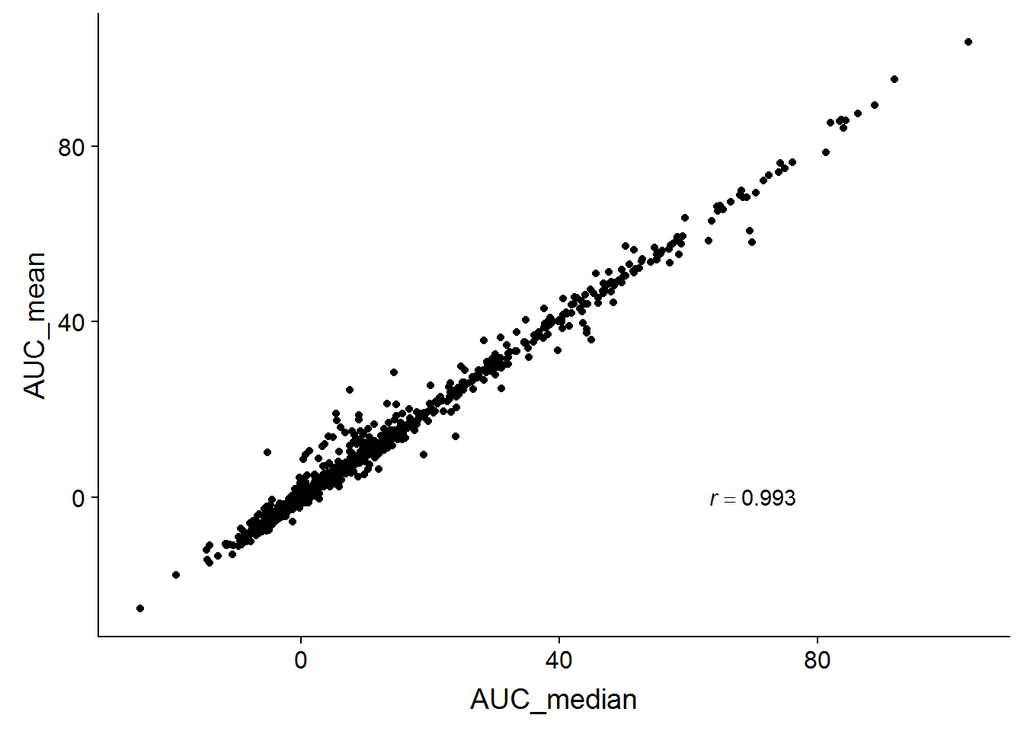

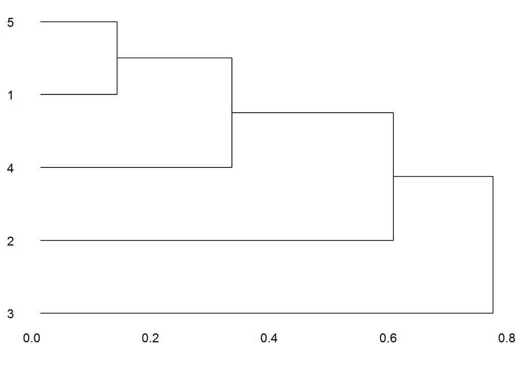

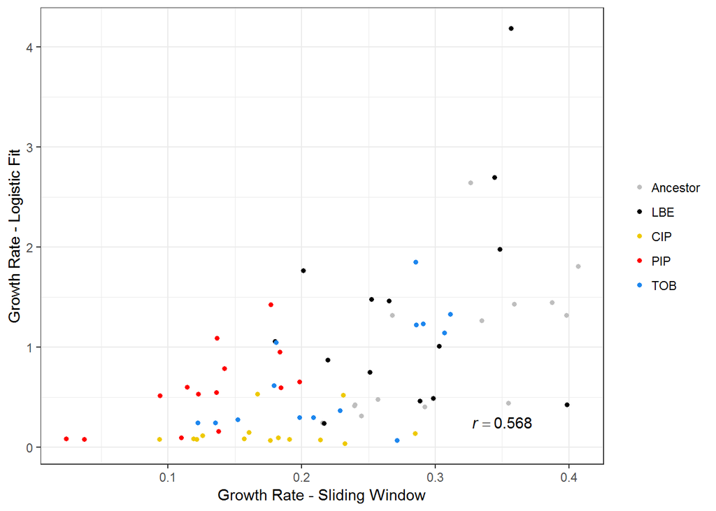

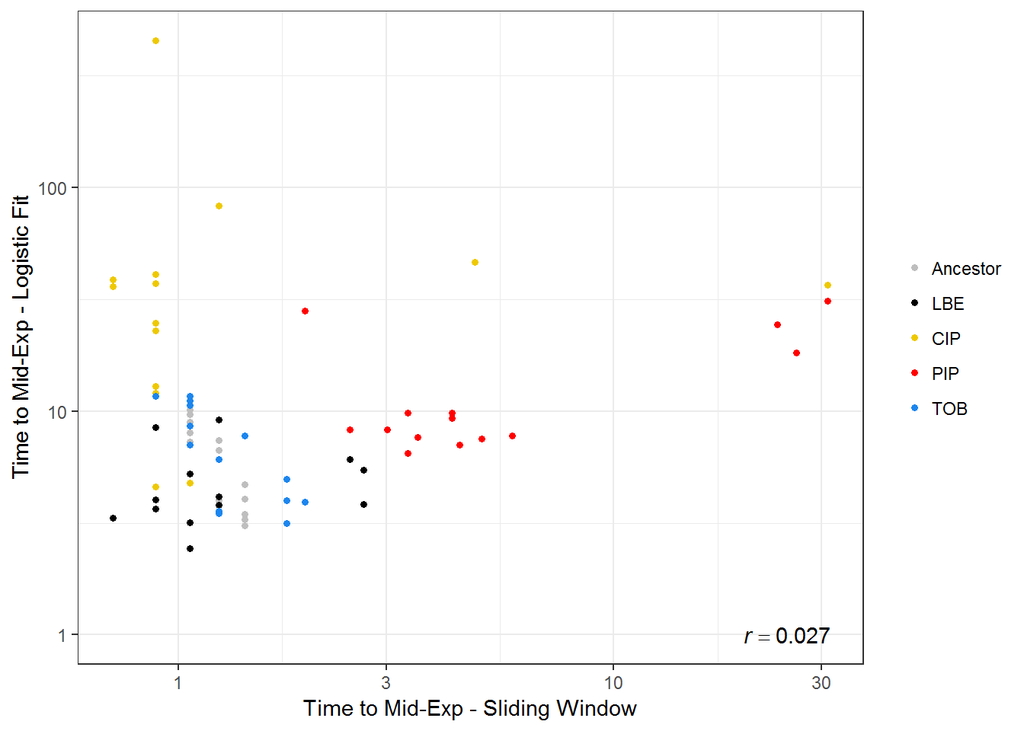